# initial_code_analysis

```python
import pandas as pd
import numpy as np
```

loading imdb movies

```python
imdb_titles = pd.read_csv('IMDb movies.csv', encoding="utf-8", na_values="Unknown", encoding_errors="replace")
imdb_titles
```

|  | imdb_title_id | title | original_title | year | date_published | genre | duration | country | language | director | ... | actors | description | avg_vote | votes | budget | usa_gross_income | worlwide_gross_income | metascore | reviews_from_users | reviews_from_critics |
| --- | --- | --- | --- | --- | --- | --- | --- | --- | --- | --- | --- | --- | --- | --- | --- | --- | --- | --- | --- | --- | --- |
| 0 | tt0000009 | Miss Jerry | Miss Jerry | 1894 | 1894-10-09 | Romance | 45 | USA | NaN | Alexander Black | ... | Blanche Bayliss, William Courtenay, Chauncey D... | The adventures of a female reporter in the 1890s. | 5.9 | 154 | NaN | NaN | NaN | NaN | 1.0 | 2.0 |
| 1 | tt0000574 | The Story of the Kelly Gang | The Story of the Kelly Gang | 1906 | 1906-12-26 | Biography, Crime, Drama | 70 | Australia | NaN | Charles Tait | ... | Elizabeth Tait, John Tait, Norman Campbell, Be... | True story of notorious Australian outlaw Ned ... | 6.1 | 589 | $ 2250 | NaN | NaN | NaN | 7.0 | 7.0 |
| 2 | tt0001892 | Den sorte dr�m | Den sorte dr�m | 1911 | 1911-08-19 | Drama | 53 | Germany, Denmark | NaN | Urban Gad | ... | Asta Nielsen, Valdemar Psilander, Gunnar Helse... | Two men of high rank are both wooing the beaut... | 5.8 | 188 | NaN | NaN | NaN | NaN | 5.0 | 2.0 |
| 3 | tt0002101 | Cleopatra | Cleopatra | 1912 | 1912-11-13 | Drama, History | 100 | USA | English | Charles L. Gaskill | ... | Helen Gardner, Pearl Sindelar, Miss Fielding, ... | The fabled queen of Egypt's affair with Roman ... | 5.2 | 446 | $ 45000 | NaN | NaN | NaN | 25.0 | 3.0 |
| 4 | tt0002130 | L'Inferno | L'Inferno | 1911 | 1911-03-06 | Adventure, Drama, Fantasy | 68 | Italy | Italian | Francesco Bertolini, Adolfo Padovan | ... | Salvatore Papa, Arturo Pirovano, Giuseppe de L... | Loosely adapted from Dante's Divine Comedy and... | 7.0 | 2237 | NaN | NaN | NaN | NaN | 31.0 | 14.0 |
| ... | ... | ... | ... | ... | ... | ... | ... | ... | ... | ... | ... | ... | ... | ... | ... | ... | ... | ... | ... | ... | ... |
| 85850 | tt9908390 | Le lion | Le lion | 2020 | 2020-01-29 | Comedy | 95 | France, Belgium | French | Ludovic Colbeau-Justin | ... | Dany Boon, Philippe Katerine, Anne Serra, Samu... | A psychiatric hospital patient pretends to be ... | 5.3 | 398 | NaN | NaN | $ 3507171 | NaN | NaN | 4.0 |
| 85851 | tt9911196 | De Beentjes van Sint-Hildegard | De Beentjes van Sint-Hildegard | 2020 | 2020-02-13 | Comedy, Drama | 103 | Netherlands | German, Dutch | Johan Nijenhuis | ... | Herman Finkers, Johanna ter Steege, Leonie ter... | A middle-aged veterinary surgeon believes his ... | 7.7 | 724 | NaN | NaN | $ 7299062 | NaN | 6.0 | 4.0 |
| 85852 | tt9911774 | Padmavyuhathile Abhimanyu | Padmavyuhathile Abhimanyu | 2019 | 2019-03-08 | Drama | 130 | India | Malayalam | Vineesh Aaradya | ... | Anoop Chandran, Indrans, Sona Nair, Simon Brit... | NaN | 7.9 | 265 | NaN | NaN | NaN | NaN | NaN | NaN |
| 85853 | tt9914286 | Sokagin �ocuklari | Sokagin �ocuklari | 2019 | 2019-03-15 | Drama, Family | 98 | Turkey | Turkish | Ahmet Faik Akinci | ... | Ahmet Faik Akinci, Belma Mamati, Metin Ke�eci,... | NaN | 6.4 | 194 | NaN | NaN | $ 2833 | NaN | NaN | NaN |
| 85854 | tt9914942 | La vida sense la Sara Amat | La vida sense la Sara Amat | 2019 | 2020-02-05 | Drama | 74 | Spain | Catalan | Laura Jou | ... | Maria Morera Colomer, Biel Rossell Pelfort, Is... | Pep, a 13-year-old boy, is in love with a girl... | 6.7 | 102 | NaN | NaN | $ 59794 | NaN | NaN | 2.0 |

85855 rows × 22 columns

loading imdb ratings

```python
imdb_ratings = pd.read_csv("IMDb ratings.csv", usecols=["imdb_title_id", "weighted_average_vote"])
imdb_ratings
```

|  | imdb_title_id | weighted_average_vote |
| --- | --- | --- |
| 0 | tt0000009 | 5.9 |
| 1 | tt0000574 | 6.1 |
| 2 | tt0001892 | 5.8 |
| 3 | tt0002101 | 5.2 |
| 4 | tt0002130 | 7.0 |
| ... | ... | ... |
| 85850 | tt9908390 | 5.3 |
| 85851 | tt9911196 | 7.7 |
| 85852 | tt9911774 | 7.9 |
| 85853 | tt9914286 | 6.4 |
| 85854 | tt9914942 | 6.7 |

85855 rows × 2 columns

Merging imdb titles with imdb ratings with inner join

```python
imdb = imdb_titles.merge(imdb_ratings, left_on="imdb_title_id", right_on="imdb_title_id", how="inner")
imdb
```

|  | imdb_title_id | title | original_title | year | date_published | genre | duration | country | language | director | ... | description | avg_vote | votes | budget | usa_gross_income | worlwide_gross_income | metascore | reviews_from_users | reviews_from_critics | weighted_average_vote |
| --- | --- | --- | --- | --- | --- | --- | --- | --- | --- | --- | --- | --- | --- | --- | --- | --- | --- | --- | --- | --- | --- |
| 0 | tt0000009 | Miss Jerry | Miss Jerry | 1894 | 1894-10-09 | Romance | 45 | USA | NaN | Alexander Black | ... | The adventures of a female reporter in the 1890s. | 5.9 | 154 | NaN | NaN | NaN | NaN | 1.0 | 2.0 | 5.9 |
| 1 | tt0000574 | The Story of the Kelly Gang | The Story of the Kelly Gang | 1906 | 1906-12-26 | Biography, Crime, Drama | 70 | Australia | NaN | Charles Tait | ... | True story of notorious Australian outlaw Ned ... | 6.1 | 589 | $ 2250 | NaN | NaN | NaN | 7.0 | 7.0 | 6.1 |
| 2 | tt0001892 | Den sorte dr�m | Den sorte dr�m | 1911 | 1911-08-19 | Drama | 53 | Germany, Denmark | NaN | Urban Gad | ... | Two men of high rank are both wooing the beaut... | 5.8 | 188 | NaN | NaN | NaN | NaN | 5.0 | 2.0 | 5.8 |
| 3 | tt0002101 | Cleopatra | Cleopatra | 1912 | 1912-11-13 | Drama, History | 100 | USA | English | Charles L. Gaskill | ... | The fabled queen of Egypt's affair with Roman ... | 5.2 | 446 | $ 45000 | NaN | NaN | NaN | 25.0 | 3.0 | 5.2 |
| 4 | tt0002130 | L'Inferno | L'Inferno | 1911 | 1911-03-06 | Adventure, Drama, Fantasy | 68 | Italy | Italian | Francesco Bertolini, Adolfo Padovan | ... | Loosely adapted from Dante's Divine Comedy and... | 7.0 | 2237 | NaN | NaN | NaN | NaN | 31.0 | 14.0 | 7.0 |
| ... | ... | ... | ... | ... | ... | ... | ... | ... | ... | ... | ... | ... | ... | ... | ... | ... | ... | ... | ... | ... | ... |
| 85850 | tt9908390 | Le lion | Le lion | 2020 | 2020-01-29 | Comedy | 95 | France, Belgium | French | Ludovic Colbeau-Justin | ... | A psychiatric hospital patient pretends to be ... | 5.3 | 398 | NaN | NaN | $ 3507171 | NaN | NaN | 4.0 | 5.3 |
| 85851 | tt9911196 | De Beentjes van Sint-Hildegard | De Beentjes van Sint-Hildegard | 2020 | 2020-02-13 | Comedy, Drama | 103 | Netherlands | German, Dutch | Johan Nijenhuis | ... | A middle-aged veterinary surgeon believes his ... | 7.7 | 724 | NaN | NaN | $ 7299062 | NaN | 6.0 | 4.0 | 7.7 |
| 85852 | tt9911774 | Padmavyuhathile Abhimanyu | Padmavyuhathile Abhimanyu | 2019 | 2019-03-08 | Drama | 130 | India | Malayalam | Vineesh Aaradya | ... | NaN | 7.9 | 265 | NaN | NaN | NaN | NaN | NaN | NaN | 7.9 |
| 85853 | tt9914286 | Sokagin �ocuklari | Sokagin �ocuklari | 2019 | 2019-03-15 | Drama, Family | 98 | Turkey | Turkish | Ahmet Faik Akinci | ... | NaN | 6.4 | 194 | NaN | NaN | $ 2833 | NaN | NaN | NaN | 6.4 |
| 85854 | tt9914942 | La vida sense la Sara Amat | La vida sense la Sara Amat | 2019 | 2020-02-05 | Drama | 74 | Spain | Catalan | Laura Jou | ... | Pep, a 13-year-old boy, is in love with a girl... | 6.7 | 102 | NaN | NaN | $ 59794 | NaN | NaN | 2.0 | 6.7 |

85855 rows × 23 columns

Checking how many films are released in the country

```python
imdb["country"].value_counts()
```

```
country
USA                                       28511
India                                      6065
UK                                         4111
Japan                                      3077
France                                     3055
                                          ...
Denmark, Iceland, Norway                      1
Mexico, France, Belgium, Germany              1
UK, Germany, Kenya, France, USA, China        1
Germany, Ireland, Taiwan                      1
India, Netherlands, Singapore                 1
Name: count, Length: 4907, dtype: int64
```

```python
imdb_country = imdb.copy(deep=True)
imdb_country["country"] = imdb_country["country"].astype(str).str.split(", ")
imdb_country = imdb_country.explode("country", ignore_index=True)
imdb_country["country"].value_counts()
```

```
country
USA                       34325
France                     8311
UK                         7490
India                      6373
Italy                      5056
                          ...
New Caledonia                 1
Mauritius                     1
Guinea-Bissau                 1
Svalbard And Jan Mayen        1
Oman                          1
Name: count, Length: 195, dtype: int64
```

```python
country_df = imdb.copy(deep=True)
country_df["country"] = country_df["country"].astype(str).str.split(", ")
country_df = country_df.explode("country", ignore_index=True)
country_df.head()
```

|  | imdb_title_id | title | original_title | year | date_published | genre | duration | country | language | director | ... | description | avg_vote | votes | budget | usa_gross_income | worlwide_gross_income | metascore | reviews_from_users | reviews_from_critics | weighted_average_vote |
| --- | --- | --- | --- | --- | --- | --- | --- | --- | --- | --- | --- | --- | --- | --- | --- | --- | --- | --- | --- | --- | --- |
| 0 | tt0000009 | Miss Jerry | Miss Jerry | 1894 | 1894-10-09 | Romance | 45 | USA | NaN | Alexander Black | ... | The adventures of a female reporter in the 1890s. | 5.9 | 154 | NaN | NaN | NaN | NaN | 1.0 | 2.0 | 5.9 |
| 1 | tt0000574 | The Story of the Kelly Gang | The Story of the Kelly Gang | 1906 | 1906-12-26 | Biography, Crime, Drama | 70 | Australia | NaN | Charles Tait | ... | True story of notorious Australian outlaw Ned ... | 6.1 | 589 | $ 2250 | NaN | NaN | NaN | 7.0 | 7.0 | 6.1 |
| 2 | tt0001892 | Den sorte dr�m | Den sorte dr�m | 1911 | 1911-08-19 | Drama | 53 | Germany | NaN | Urban Gad | ... | Two men of high rank are both wooing the beaut... | 5.8 | 188 | NaN | NaN | NaN | NaN | 5.0 | 2.0 | 5.8 |
| 3 | tt0001892 | Den sorte dr�m | Den sorte dr�m | 1911 | 1911-08-19 | Drama | 53 | Denmark | NaN | Urban Gad | ... | Two men of high rank are both wooing the beaut... | 5.8 | 188 | NaN | NaN | NaN | NaN | 5.0 | 2.0 | 5.8 |
| 4 | tt0002101 | Cleopatra | Cleopatra | 1912 | 1912-11-13 | Drama, History | 100 | USA | English | Charles L. Gaskill | ... | The fabled queen of Egypt's affair with Roman ... | 5.2 | 446 | $ 45000 | NaN | NaN | NaN | 25.0 | 3.0 | 5.2 |

5 rows × 23 columns

```python
country_df["country"].value_counts()
```

```
country
USA                       34325
France                     8311
UK                         7490
India                      6373
Italy                      5056
                          ...
New Caledonia                 1
Mauritius                     1
Guinea-Bissau                 1
Svalbard And Jan Mayen        1
Oman                          1
Name: count, Length: 195, dtype: int64
```

```python
sorted_country_counts = country_df.groupby(by="country").size().reset_index(name="counts")
top_10_country = sorted_country_counts.sort_values(by="counts", ascending=False).head(10)
```

```python
top_10_country = pd.DataFrame(top_10_country)
```

```python
top_10_country = top_10_country._append({'country':"others", 'counts':31633 }, ignore_index=True)
```

```python
top_10_country
```

|  | country | counts |
| --- | --- | --- |
| 0 | USA | 34325 |
| 1 | France | 8311 |
| 2 | UK | 7490 |
| 3 | India | 6373 |
| 4 | Italy | 5056 |
| 5 | Germany | 3721 |
| 6 | Japan | 3701 |
| 7 | Canada | 3621 |
| 8 | Spain | 2731 |
| 9 | Hong Kong | 1884 |
| 10 | others | 31633 |

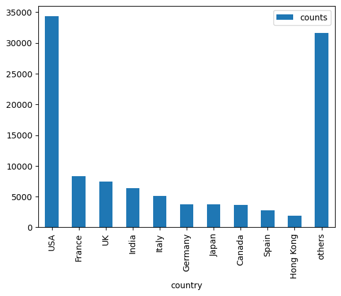

```python
top_10_country.plot(x="country", y="counts", kind="bar")
```

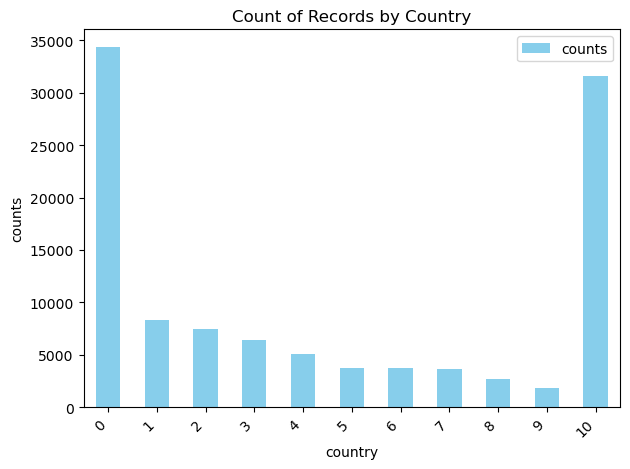

```python
plt.figure(figsize=(10, 8))
top_10_country.plot(kind='bar', color='skyblue')
plt.title('Count of Records by Country')
plt.xlabel('country')
plt.ylabel('counts')
plt.xticks(rotation=45, ha='right')  # Rotate x-axis labels for better readability
plt.tight_layout()
plt.show()
```

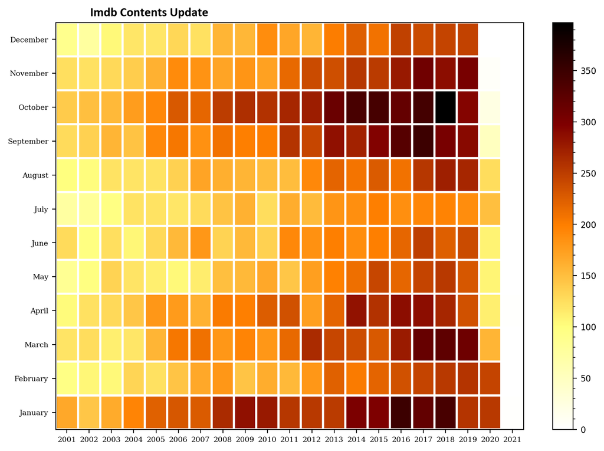

```python
netflix_date = imdb[['date_published']].dropna()
month_order = ['January', 'February', 'March', 'April', 'May', 'June', 'July', 'August', 'September', 'October',
               'November', 'December']
netflix_date['year'] = netflix_date['date_published'].apply(
    lambda x: int(x.split("-")[0]) if x != "TV Movie 2019" else 2019)
netflix_date['month'] = netflix_date['date_published'].apply(
    lambda x: month_order[int(x.lstrip().split('-')[1]) - 1] if len(x.lstrip().split('-')) == 3 else month_order[0])
netflix_date = netflix_date[netflix_date["year"] > 2000]

df = netflix_date.groupby('year')['month'].value_counts().unstack().fillna(0)[month_order].T
plt.figure(figsize=(10, 7), dpi=200)
plt.pcolor(df, cmap='afmhot_r', edgecolors='white', linewidths=2)  # heatmap
plt.xticks(np.arange(0.5, len(df.columns), 1), df.columns, fontsize=7, fontfamily='serif')
plt.yticks(np.arange(0.5, len(df.index), 1), df.index, fontsize=7, fontfamily='serif')

plt.title('Imdb Contents Update', fontsize=12, fontfamily='calibri', fontweight='bold', position=(0.20, 1.0 + 0.02))
cbar = plt.colorbar()

cbar.ax.tick_params(labelsize=8)
cbar.ax.minorticks_on()
plt.show()
```

```python
languages_df = imdb.copy(deep=True)
languages_df["language"] = languages_df["language"].astype(str).str.split(", ")
languages_df = languages_df.explode("language", ignore_index=True)
lang_count= languages_df.groupby(by="language").size().reset_index(name="count")
lang_count
```

|  | language | count |
| --- | --- | --- |
| 0 | Abkhazian | 2 |
| 1 | Aboriginal | 32 |
| 2 | Acholi | 1 |
| 3 | Afrikaans | 116 |
| 4 | Akan | 4 |
| ... | ... | ... |
| 263 | Yakut | 3 |
| 264 | Yiddish | 124 |
| 265 | Yoruba | 11 |
| 266 | Zulu | 38 |
| 267 | nan | 901 |

268 rows × 2 columns

```python
top_10_lang = lang_count.sort_values(by="count", ascending=False).head(10)
top_10_lang = pd.DataFrame(top_10_lang)
top_10_lang
```

|  | language | count |
| --- | --- | --- |
| 62 | English | 47446 |
| 70 | French | 8156 |
| 224 | Spanish | 5682 |
| 103 | Italian | 4677 |
| 76 | German | 4504 |
| 104 | Japanese | 3884 |
| 92 | Hindi | 2949 |
| 196 | Russian | 2814 |
| 141 | Mandarin | 1946 |
| 247 | Turkish | 1666 |

```python
top_10_lang["count"].sum() - lang_count["count"].sum()
```

```
-26330
```

```python
top_10_lang = top_10_lang._append({'language': "others", 'count': 26330}, ignore_index=True)
```

```python
top_10_lang
```

|  | language | count |
| --- | --- | --- |
| 0 | English | 47446 |
| 1 | French | 8156 |
| 2 | Spanish | 5682 |
| 3 | Italian | 4677 |
| 4 | German | 4504 |
| 5 | Japanese | 3884 |
| 6 | Hindi | 2949 |
| 7 | Russian | 2814 |
| 8 | Mandarin | 1946 |
| 9 | Turkish | 1666 |
| 10 | others | 26330 |

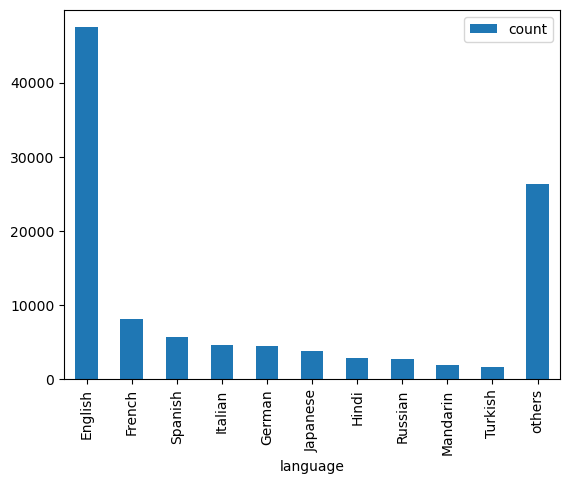

```python
top_10_lang.plot(x="language", y="count", kind="bar")
```

```python
languages_df = imdb.copy(deep=True)
languages_df["genre"] = languages_df["genre"].astype(str).str.split(", ")
languages_df = languages_df.explode("genre", ignore_index=True)
lang_count= languages_df.groupby(by="genre").size().reset_index(name="count")
lang_count
```

|  | genre | count |
| --- | --- | --- |
| 0 | Action | 12948 |
| 1 | Adult | 2 |
| 2 | Adventure | 7590 |
| 3 | Animation | 2141 |
| 4 | Biography | 2377 |
| 5 | Comedy | 29368 |
| 6 | Crime | 11067 |
| 7 | Documentary | 2 |
| 8 | Drama | 47110 |
| 9 | Family | 3962 |
| 10 | Fantasy | 3812 |
| 11 | Film-Noir | 663 |
| 12 | History | 2296 |
| 13 | Horror | 9557 |
| 14 | Music | 1689 |
| 15 | Musical | 2041 |
| 16 | Mystery | 5225 |
| 17 | News | 1 |
| 18 | Reality-TV | 3 |
| 19 | Romance | 14128 |
| 20 | Sci-Fi | 3608 |
| 21 | Sport | 1064 |
| 22 | Thriller | 11388 |
| 23 | War | 2242 |
| 24 | Western | 1583 |

```python
top_10_lang = lang_count.sort_values(by="count", ascending=False)
top_10_lang = pd.DataFrame(top_10_lang)
top_10_lang
```

|  | genre | count |
| --- | --- | --- |
| 8 | Drama | 47110 |
| 5 | Comedy | 29368 |
| 19 | Romance | 14128 |
| 0 | Action | 12948 |
| 22 | Thriller | 11388 |
| 6 | Crime | 11067 |
| 13 | Horror | 9557 |
| 2 | Adventure | 7590 |
| 16 | Mystery | 5225 |
| 9 | Family | 3962 |
| 10 | Fantasy | 3812 |
| 20 | Sci-Fi | 3608 |
| 4 | Biography | 2377 |
| 12 | History | 2296 |
| 23 | War | 2242 |
| 3 | Animation | 2141 |
| 15 | Musical | 2041 |
| 14 | Music | 1689 |
| 24 | Western | 1583 |
| 21 | Sport | 1064 |
| 11 | Film-Noir | 663 |
| 18 | Reality-TV | 3 |
| 1 | Adult | 2 |
| 7 | Documentary | 2 |
| 17 | News | 1 |

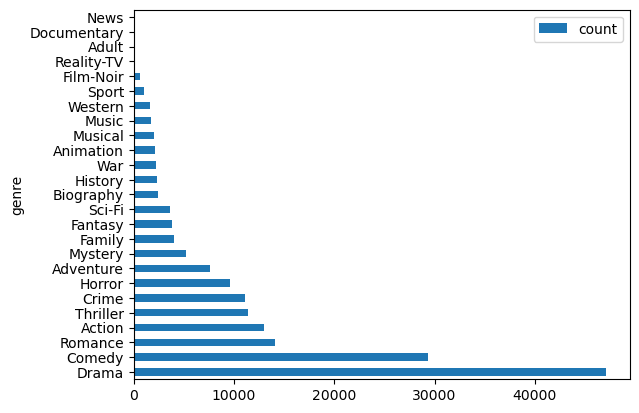

```python
top_10_lang.plot(x="genre", y="count", kind="barh")
```

Now we are taking the movies which released only in India

```python
indian_movies = imdb[imdb["country"] == "India"]
indian_movies
```

|  | imdb_title_id | title | original_title | year | date_published | genre | duration | country | language | director | ... | description | avg_vote | votes | budget | usa_gross_income | worlwide_gross_income | metascore | reviews_from_users | reviews_from_critics | weighted_average_vote |
| --- | --- | --- | --- | --- | --- | --- | --- | --- | --- | --- | --- | --- | --- | --- | --- | --- | --- | --- | --- | --- | --- |
| 1016 | tt0021594 | Alam Ara | Alam Ara | 1931 | 1931-03-14 | Drama, Fantasy | 124 | India | Hindi, Urdu | Ardeshir Irani | ... | A period fantasy that told of the ageing king ... | 6.3 | 106 | NaN | NaN | NaN | NaN | NaN | 1.0 | 6.3 |
| 2308 | tt0027256 | Achhut Kanya | Achhut Kanya | 1936 | 1936 | Drama, Musical, Romance | 142 | India | Hindi, Urdu | Franz Osten | ... | An "untouchable" girl and a Brahmin boy fall i... | 6.5 | 104 | NaN | NaN | NaN | NaN | 2.0 | 1.0 | 6.5 |
| 2514 | tt0028217 | Sant Tukaram | Sant Tukaram | 1936 | 2013-10-24 | Biography | 131 | India | Marathi, Hindi | Vishnupant Govind Damle, Sheikh Fattelal | ... | This classic film chronicles the life of Tukar... | 6.7 | 218 | NaN | NaN | NaN | NaN | 3.0 | 1.0 | 6.7 |
| 5736 | tt0040067 | Aag | Aag | 1948 | 1948-08-06 | Musical, Romance | 138 | India | Hindi | Raj Kapoor | ... | Failing to move on from his loss of childhood ... | 7.5 | 343 | NaN | NaN | NaN | NaN | 5.0 | 2.0 | 7.5 |
| 6072 | tt0041123 | Andaz | Andaz | 1949 | 1949 | Musical, Drama, Crime | 148 | India | Hindi | Mehboob Khan | ... | Dilip loves Neena, but she treats him only as ... | 7.4 | 460 | NaN | NaN | NaN | NaN | 7.0 | 3.0 | 7.4 |
| ... | ... | ... | ... | ... | ... | ... | ... | ... | ... | ... | ... | ... | ... | ... | ... | ... | ... | ... | ... | ... | ... |
| 85844 | tt9903716 | Jessie | Jessie | 2019 | 2019-03-15 | Horror, Thriller | 106 | India | Telugu | Aswani Kumar V. | ... | Set in an abandoned house, the film follows a ... | 7.0 | 318 | NaN | NaN | NaN | NaN | 27.0 | NaN | 7.0 |
| 85847 | tt9905412 | Ottam | Ottam | 2019 | 2019-03-08 | Drama | 120 | India | Malayalam | Zam | ... | Set in Trivandrum, the story of Ottam unfolds ... | 7.4 | 494 | INR 4000000 | NaN | $ 4791 | NaN | 1.0 | NaN | 7.4 |
| 85848 | tt9905462 | Pengalila | Pengalila | 2019 | 2019-03-08 | Drama | 111 | India | Malayalam | T.V. Chandran | ... | An unusual bond between a sixty year old Dalit... | 8.8 | 553 | INR 10000000 | NaN | NaN | NaN | NaN | NaN | 8.8 |
| 85849 | tt9906644 | Manoharam | Manoharam | 2019 | 2019-09-27 | Comedy, Drama | 122 | India | Malayalam | Anvar Sadik | ... | Manoharan is a poster artist struggling to fin... | 6.8 | 491 | NaN | NaN | NaN | NaN | 9.0 | 1.0 | 6.8 |
| 85852 | tt9911774 | Padmavyuhathile Abhimanyu | Padmavyuhathile Abhimanyu | 2019 | 2019-03-08 | Drama | 130 | India | Malayalam | Vineesh Aaradya | ... | NaN | 7.9 | 265 | NaN | NaN | NaN | NaN | NaN | NaN | 7.9 |

6065 rows × 23 columns

```python
indian_movies.info()
```

```
<class 'pandas.core.frame.DataFrame'>
Index: 6065 entries, 1016 to 85852
Data columns (total 23 columns):
 #   Column                 Non-Null Count  Dtype
---  ------                 --------------  -----
 0   imdb_title_id          6065 non-null   object
 1   title                  6065 non-null   object
 2   original_title         6065 non-null   object
 3   year                   6065 non-null   object
 4   date_published         6065 non-null   object
 5   genre                  6065 non-null   object
 6   duration               6065 non-null   int64
 7   country                6065 non-null   object
 8   language               6038 non-null   object
 9   director               6052 non-null   object
 10  writer                 5433 non-null   object
 11  production_company     5337 non-null   object
 12  actors                 6065 non-null   object
 13  description            5985 non-null   object
 14  avg_vote               6065 non-null   float64
 15  votes                  6065 non-null   int64
 16  budget                 1031 non-null   object
 17  usa_gross_income       508 non-null    object
 18  worlwide_gross_income  1806 non-null   object
 19  metascore              50 non-null     float64
 20  reviews_from_users     5380 non-null   float64
 21  reviews_from_critics   3994 non-null   float64
 22  weighted_average_vote  6065 non-null   float64
dtypes: float64(5), int64(2), object(16)
memory usage: 1.1+ MB
```

```python
indian_movies["year"] = indian_movies["year"].astype(int)
indian_movies.groupby(by="year").size()
```

```
year
1931      1
1936      2
1941      1
1946      1
1948      1
       ...
2016    324
2017    364
2018    397
2019    445
2020    141
Length: 76, dtype: int64
```

We are filtering out the data from 2000 as there are too many movies present from the following years

```python
indian_movies_since_2000 = indian_movies[indian_movies['year'] >= 2000]
indian_movies_since_2000
```

|  | imdb_title_id | title | original_title | year | date_published | genre | duration | country | language | director | ... | description | avg_vote | votes | budget | usa_gross_income | worlwide_gross_income | metascore | reviews_from_users | reviews_from_critics | weighted_average_vote |
| --- | --- | --- | --- | --- | --- | --- | --- | --- | --- | --- | --- | --- | --- | --- | --- | --- | --- | --- | --- | --- | --- |
| 29759 | tt0116391 | Gang | Gang | 2000 | 2000-04-21 | Action, Crime, Drama | 152 | India | Hindi | Mazhar Khan | ... | After falling prey to underworld, four friends... | 6.3 | 212 | NaN | $ 28915 | NaN | NaN | 4.0 | 1.0 | 6.3 |
| 29876 | tt0116748 | Karobaar: The Business of Love | Karobaar: The Business of Love | 2000 | 2000-09-15 | Drama, Romance | 180 | India | Hindi | Rakesh Roshan | ... | Wealthy Rajiv Sinha and middle-classed Amar Sa... | 4.5 | 223 | NaN | $ 45200 | $ 45200 | NaN | 3.0 | 1.0 | 4.5 |
| 30345 | tt0118578 | Albela | Albela | 2001 | 2001-04-20 | Comedy, Drama, Romance | 145 | India | Hindi | Deepak Sareen | ... | Tony (Govinda) works as a guide, helping touri... | 3.7 | 695 | NaN | NaN | NaN | NaN | 7.0 | 1.0 | 3.7 |
| 30999 | tt0120117 | Shikari | Shikari | 2000 | 2000-10-06 | Crime, Drama, Thriller | 160 | India | Hindi | N. Chandra | ... | Filled with vengeance, a simple man turns into... | 4.5 | 396 | NaN | $ 40712 | $ 40712 | NaN | 5.0 | 4.0 | 4.5 |
| 33192 | tt0151150 | Josh | Josh | 2000 | 2000-06-09 | Action, Drama, Musical | 162 | India | Hindi | Mansoor Khan | ... | Shah Rukh Khan and Sharad Kapoor are the leade... | 6.1 | 9258 | NaN | $ 426318 | $ 426318 | NaN | 10.0 | 1.0 | 6.1 |
| ... | ... | ... | ... | ... | ... | ... | ... | ... | ... | ... | ... | ... | ... | ... | ... | ... | ... | ... | ... | ... | ... |
| 85844 | tt9903716 | Jessie | Jessie | 2019 | 2019-03-15 | Horror, Thriller | 106 | India | Telugu | Aswani Kumar V. | ... | Set in an abandoned house, the film follows a ... | 7.0 | 318 | NaN | NaN | NaN | NaN | 27.0 | NaN | 7.0 |
| 85847 | tt9905412 | Ottam | Ottam | 2019 | 2019-03-08 | Drama | 120 | India | Malayalam | Zam | ... | Set in Trivandrum, the story of Ottam unfolds ... | 7.4 | 494 | INR 4000000 | NaN | $ 4791 | NaN | 1.0 | NaN | 7.4 |
| 85848 | tt9905462 | Pengalila | Pengalila | 2019 | 2019-03-08 | Drama | 111 | India | Malayalam | T.V. Chandran | ... | An unusual bond between a sixty year old Dalit... | 8.8 | 553 | INR 10000000 | NaN | NaN | NaN | NaN | NaN | 8.8 |
| 85849 | tt9906644 | Manoharam | Manoharam | 2019 | 2019-09-27 | Comedy, Drama | 122 | India | Malayalam | Anvar Sadik | ... | Manoharan is a poster artist struggling to fin... | 6.8 | 491 | NaN | NaN | NaN | NaN | 9.0 | 1.0 | 6.8 |
| 85852 | tt9911774 | Padmavyuhathile Abhimanyu | Padmavyuhathile Abhimanyu | 2019 | 2019-03-08 | Drama | 130 | India | Malayalam | Vineesh Aaradya | ... | NaN | 7.9 | 265 | NaN | NaN | NaN | NaN | NaN | NaN | 7.9 |

4431 rows × 23 columns

Checking is there in duplicated title ids

```python
indian_movies_since_2000.duplicated("imdb_title_id").sum()
```

```
0
```

```python
indian_movies_since_2000.isna().sum()
```

```
imdb_title_id               0
title                       0
original_title              0
year                        0
date_published              0
genre                       0
duration                    0
country                     0
language                   22
director                   12
writer                    421
production_company        326
actors                      0
description                42
avg_vote                    0
votes                       0
budget                   3442
usa_gross_income         3953
worlwide_gross_income    2676
metascore                4383
reviews_from_users        428
reviews_from_critics     1135
weighted_average_vote       0
dtype: int64
```

```python
indian_movies_since_2000.shape
```

```
(4431, 23)
```

As language and description are more important column we are droping the movies which has null value in language and description

```python
indian_movies_since_2000 = indian_movies_since_2000.dropna(subset=["language", "description"])
```

```python
indian_movies_since_2000.isna().sum()
```

```
imdb_title_id               0
title                       0
original_title              0
year                        0
date_published              0
genre                       0
duration                    0
country                     0
language                    0
director                   12
writer                    406
production_company        318
actors                      0
description                 0
avg_vote                    0
votes                       0
budget                   3391
usa_gross_income         3891
worlwide_gross_income    2623
metascore                4320
reviews_from_users        409
reviews_from_critics     1097
weighted_average_vote       0
dtype: int64
```

```python
indian_movies_since_2000.shape
```

```
(4368, 23)
```

Total 63 movies are dropped from the dataset

Again checking whether there are any duplicate title ids

```python
indian_movies_since_2000.duplicated("imdb_title_id").sum()
```

```
0
```

Seeing the language distribution

```python
indian_movies_since_2000.groupby(by="language").size().sort_values(ascending=False)
```

```
language
Hindi                               1217
Tamil                                661
Malayalam                            603
Telugu                               533
Bengali                              261
                                    ...
Hindi, Tamil, English, French          1
Hindi, Tamil, English, Marathi         1
Hindi, Tamil, Rajasthani               1
Hindi, English, Chinese, Spanish       1
Hindi, Punjabi, Marathi                1
Length: 215, dtype: int64
```

As there are multiple language, creating another movie dataset which contains only single language by splitting and creting with duplicate ids

```python
import random

indian_movies_languages = pd.DataFrame(columns=['imdb_title_id', 'title', 'original_title', 'year', 'date_published',
                                                'genre', 'duration', 'country', 'language', 'director', 'writer',
                                                'production_company', 'actors', 'description', 'avg_vote', 'votes',
                                                'budget', 'usa_gross_income', 'worlwide_gross_income', 'metascore',
                                                'reviews_from_users', 'reviews_from_critics', 'weighted_average_vote'])
for index, row in indian_movies_since_2000.iterrows():
    lan = str(row["language"]).split(", ")
    if len(lan) != 1:
        for i in range(len(lan)):
            new_row = row.copy(deep=True)
            while True:
                title_id = "tt" + str(random.randint(1000000, 2000000))
                if title_id not in indian_movies_since_2000["imdb_title_id"].to_list() and title_id not in \
                        indian_movies_languages["imdb_title_id"].to_list():
                    new_row["imdb_title_id"] = title_id
                    break
            new_row["title"] = str(new_row["title"]) + f"({lan[i]})"
            new_row["language"] = lan[i]
            indian_movies_languages = indian_movies_languages._append(new_row)
    else:
        indian_movies_languages = indian_movies_languages._append(row)
indian_movies_languages
```

|  | imdb_title_id | title | original_title | year | date_published | genre | duration | country | language | director | ... | description | avg_vote | votes | budget | usa_gross_income | worlwide_gross_income | metascore | reviews_from_users | reviews_from_critics | weighted_average_vote |
| --- | --- | --- | --- | --- | --- | --- | --- | --- | --- | --- | --- | --- | --- | --- | --- | --- | --- | --- | --- | --- | --- |
| 29759 | tt0116391 | Gang | Gang | 2000 | 2000-04-21 | Action, Crime, Drama | 152 | India | Hindi | Mazhar Khan | ... | After falling prey to underworld, four friends... | 6.3 | 212 | NaN | $ 28915 | NaN | NaN | 4.0 | 1.0 | 6.3 |
| 29876 | tt0116748 | Karobaar: The Business of Love | Karobaar: The Business of Love | 2000 | 2000-09-15 | Drama, Romance | 180 | India | Hindi | Rakesh Roshan | ... | Wealthy Rajiv Sinha and middle-classed Amar Sa... | 4.5 | 223 | NaN | $ 45200 | $ 45200 | NaN | 3.0 | 1.0 | 4.5 |
| 30345 | tt0118578 | Albela | Albela | 2001 | 2001-04-20 | Comedy, Drama, Romance | 145 | India | Hindi | Deepak Sareen | ... | Tony (Govinda) works as a guide, helping touri... | 3.7 | 695 | NaN | NaN | NaN | NaN | 7.0 | 1.0 | 3.7 |
| 30999 | tt0120117 | Shikari | Shikari | 2000 | 2000-10-06 | Crime, Drama, Thriller | 160 | India | Hindi | N. Chandra | ... | Filled with vengeance, a simple man turns into... | 4.5 | 396 | NaN | $ 40712 | $ 40712 | NaN | 5.0 | 4.0 | 4.5 |
| 33192 | tt0151150 | Josh | Josh | 2000 | 2000-06-09 | Action, Drama, Musical | 162 | India | Hindi | Mansoor Khan | ... | Shah Rukh Khan and Sharad Kapoor are the leade... | 6.1 | 9258 | NaN | $ 426318 | $ 426318 | NaN | 10.0 | 1.0 | 6.1 |
| ... | ... | ... | ... | ... | ... | ... | ... | ... | ... | ... | ... | ... | ... | ... | ... | ... | ... | ... | ... | ... | ... |
| 85843 | tt9900782 | Kaithi | Kaithi | 2019 | 2019-10-25 | Action, Thriller | 145 | India | Tamil | Lokesh Kanagaraj | ... | A recently released prisoner becomes involved ... | 8.5 | 8400 | INR 240000000 | NaN | $ 524061 | NaN | 188.0 | 8.0 | 8.5 |
| 85844 | tt9903716 | Jessie | Jessie | 2019 | 2019-03-15 | Horror, Thriller | 106 | India | Telugu | Aswani Kumar V. | ... | Set in an abandoned house, the film follows a ... | 7.0 | 318 | NaN | NaN | NaN | NaN | 27.0 | NaN | 7.0 |
| 85847 | tt9905412 | Ottam | Ottam | 2019 | 2019-03-08 | Drama | 120 | India | Malayalam | Zam | ... | Set in Trivandrum, the story of Ottam unfolds ... | 7.4 | 494 | INR 4000000 | NaN | $ 4791 | NaN | 1.0 | NaN | 7.4 |
| 85848 | tt9905462 | Pengalila | Pengalila | 2019 | 2019-03-08 | Drama | 111 | India | Malayalam | T.V. Chandran | ... | An unusual bond between a sixty year old Dalit... | 8.8 | 553 | INR 10000000 | NaN | NaN | NaN | NaN | NaN | 8.8 |
| 85849 | tt9906644 | Manoharam | Manoharam | 2019 | 2019-09-27 | Comedy, Drama | 122 | India | Malayalam | Anvar Sadik | ... | Manoharan is a poster artist struggling to fin... | 6.8 | 491 | NaN | NaN | NaN | NaN | 9.0 | 1.0 | 6.8 |

5394 rows × 23 columns

After creating dataframe by splitting chceking the shape

```python
indian_movies_languages.shape
```

```
(5394, 23)
```

Checking whether there are any duplicate ids

```python
indian_movies_languages.duplicated("imdb_title_id").sum()
```

```
0
```

Seeing the distribution using languages

```python
languages = indian_movies_languages.groupby(by="language").size().reset_index(name="count")
languages = languages.sort_values(by="count",ascending=False)
languages
```

|  | language | count |
| --- | --- | --- |
| 18 | Hindi | 1742 |
| 46 | Tamil | 854 |
| 47 | Telugu | 726 |
| 30 | Malayalam | 651 |
| 10 | English | 365 |
| 3 | Bengali | 313 |
| 24 | Kannada | 190 |
| 33 | Marathi | 175 |
| 40 | Punjabi | 160 |
| 52 | Urdu | 55 |
| 14 | Gujarati | 49 |
| 11 | French | 11 |
| 42 | Russian | 9 |
| 41 | Rajasthani | 8 |
| 1 | Assamese | 8 |
| 0 | Arabic | 8 |
| 5 | Bhojpuri | 7 |
| 45 | Spanish | 5 |
| 50 | Tulu | 5 |
| 23 | Japanese | 4 |
| 15 | Haryanvi | 4 |
| 22 | Italian | 3 |
| 2 | Awadhi | 3 |
| 48 | Thai | 2 |
| 13 | German | 2 |
| 20 | Indian Sign Language | 2 |
| 34 | Nepali | 2 |
| 25 | Kashmiri | 2 |
| 8 | Dari | 2 |
| 7 | Chinese | 2 |
| 51 | Turkish | 2 |
| 39 | Portuguese | 1 |
| 44 | Sindhi | 1 |
| 43 | Sanskrit | 1 |
| 49 | Tibetan | 1 |
| 37 | Parsee | 1 |
| 38 | Persian | 1 |
| 27 | Korean | 1 |
| 36 | Oriya | 1 |
| 35 | None | 1 |
| 32 | Manipuri | 1 |
| 31 | Mandarin | 1 |
| 29 | Maithili | 1 |
| 28 | Ladakhi | 1 |
| 26 | Konkani | 1 |
| 21 | Indonesian | 1 |
| 19 | Hopi | 1 |
| 17 | Himachali | 1 |
| 16 | Hebrew | 1 |
| 12 | Georgian | 1 |
| 9 | Dutch | 1 |
| 6 | Cantonese | 1 |
| 4 | Berber languages | 1 |
| 53 | Uzbek | 1 |

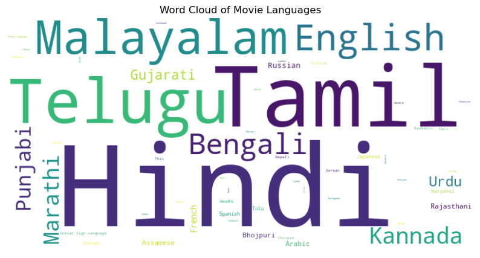

```python
from wordcloud import WordCloud
import matplotlib.pyplot as plt

# Assuming 'languages' is a pandas DataFrame with 'language' and 'count' columns
word_freq_dict = dict(zip(languages['language'], languages['count']))

# Creating a WordCloud object
wordcloud = WordCloud(width=800, height=400, background_color='white').generate_from_frequencies(word_freq_dict)

# Plotting the WordCloud
plt.figure(figsize=(10, 6))
plt.imshow(wordcloud, interpolation='bilinear')
plt.axis('off')
plt.title('Word Cloud of Movie Languages')
plt.show()
```

```python
languages_head = languages[languages["count"] >100]
languages_head
```

|  | language | count |
| --- | --- | --- |
| 18 | Hindi | 1742 |
| 46 | Tamil | 854 |
| 47 | Telugu | 726 |
| 30 | Malayalam | 651 |
| 10 | English | 365 |
| 3 | Bengali | 313 |
| 24 | Kannada | 190 |
| 33 | Marathi | 175 |
| 40 | Punjabi | 160 |

```python
languages_head["count"].sum() - languages["count"].sum()
```

```
-218
```

```python
languages_head = languages_head._append({"language":"Others","count":218}, ignore_index=True)
languages_head
```

|  | language | count |
| --- | --- | --- |
| 0 | Hindi | 1742 |
| 1 | Tamil | 854 |
| 2 | Telugu | 726 |
| 3 | Malayalam | 651 |
| 4 | English | 365 |
| 5 | Bengali | 313 |
| 6 | Kannada | 190 |
| 7 | Marathi | 175 |
| 8 | Punjabi | 160 |
| 9 | Others | 218 |

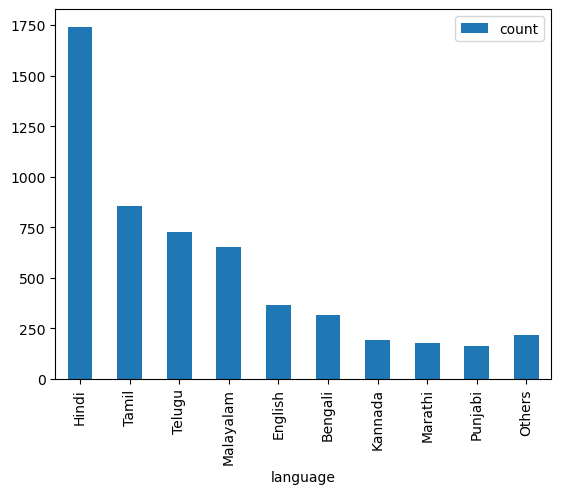

```python
languages_head.plot(x="language", y="count", kind="bar")
```

Taking languages which are more than 100

```python
languages_100 = languages[languages["count"] > 100]['language'].to_list()
languages_100
```

```
['Hindi',
 'Tamil',
 'Telugu',
 'Malayalam',
 'English',
 'Bengali',
 'Kannada',
 'Marathi',
 'Punjabi']
```

Now creating a dataframe of movies with languages which has more than 100 movies

```python
indian_movies = indian_movies_languages[indian_movies_languages["language"].astype(str).str.contains(
"|".join(languages[languages["count"] > 100]['language'].to_list()))]
indian_movies
```

|  | imdb_title_id | title | original_title | year | date_published | genre | duration | country | language | director | ... | description | avg_vote | votes | budget | usa_gross_income | worlwide_gross_income | metascore | reviews_from_users | reviews_from_critics | weighted_average_vote |
| --- | --- | --- | --- | --- | --- | --- | --- | --- | --- | --- | --- | --- | --- | --- | --- | --- | --- | --- | --- | --- | --- |
| 29759 | tt0116391 | Gang | Gang | 2000 | 2000-04-21 | Action, Crime, Drama | 152 | India | Hindi | Mazhar Khan | ... | After falling prey to underworld, four friends... | 6.3 | 212 | NaN | $ 28915 | NaN | NaN | 4.0 | 1.0 | 6.3 |
| 29876 | tt0116748 | Karobaar: The Business of Love | Karobaar: The Business of Love | 2000 | 2000-09-15 | Drama, Romance | 180 | India | Hindi | Rakesh Roshan | ... | Wealthy Rajiv Sinha and middle-classed Amar Sa... | 4.5 | 223 | NaN | $ 45200 | $ 45200 | NaN | 3.0 | 1.0 | 4.5 |
| 30345 | tt0118578 | Albela | Albela | 2001 | 2001-04-20 | Comedy, Drama, Romance | 145 | India | Hindi | Deepak Sareen | ... | Tony (Govinda) works as a guide, helping touri... | 3.7 | 695 | NaN | NaN | NaN | NaN | 7.0 | 1.0 | 3.7 |
| 30999 | tt0120117 | Shikari | Shikari | 2000 | 2000-10-06 | Crime, Drama, Thriller | 160 | India | Hindi | N. Chandra | ... | Filled with vengeance, a simple man turns into... | 4.5 | 396 | NaN | $ 40712 | $ 40712 | NaN | 5.0 | 4.0 | 4.5 |
| 33192 | tt0151150 | Josh | Josh | 2000 | 2000-06-09 | Action, Drama, Musical | 162 | India | Hindi | Mansoor Khan | ... | Shah Rukh Khan and Sharad Kapoor are the leade... | 6.1 | 9258 | NaN | $ 426318 | $ 426318 | NaN | 10.0 | 1.0 | 6.1 |
| ... | ... | ... | ... | ... | ... | ... | ... | ... | ... | ... | ... | ... | ... | ... | ... | ... | ... | ... | ... | ... | ... |
| 85843 | tt9900782 | Kaithi | Kaithi | 2019 | 2019-10-25 | Action, Thriller | 145 | India | Tamil | Lokesh Kanagaraj | ... | A recently released prisoner becomes involved ... | 8.5 | 8400 | INR 240000000 | NaN | $ 524061 | NaN | 188.0 | 8.0 | 8.5 |
| 85844 | tt9903716 | Jessie | Jessie | 2019 | 2019-03-15 | Horror, Thriller | 106 | India | Telugu | Aswani Kumar V. | ... | Set in an abandoned house, the film follows a ... | 7.0 | 318 | NaN | NaN | NaN | NaN | 27.0 | NaN | 7.0 |
| 85847 | tt9905412 | Ottam | Ottam | 2019 | 2019-03-08 | Drama | 120 | India | Malayalam | Zam | ... | Set in Trivandrum, the story of Ottam unfolds ... | 7.4 | 494 | INR 4000000 | NaN | $ 4791 | NaN | 1.0 | NaN | 7.4 |
| 85848 | tt9905462 | Pengalila | Pengalila | 2019 | 2019-03-08 | Drama | 111 | India | Malayalam | T.V. Chandran | ... | An unusual bond between a sixty year old Dalit... | 8.8 | 553 | INR 10000000 | NaN | NaN | NaN | NaN | NaN | 8.8 |
| 85849 | tt9906644 | Manoharam | Manoharam | 2019 | 2019-09-27 | Comedy, Drama | 122 | India | Malayalam | Anvar Sadik | ... | Manoharan is a poster artist struggling to fin... | 6.8 | 491 | NaN | NaN | NaN | NaN | 9.0 | 1.0 | 6.8 |

5176 rows × 23 columns

Checking the shape of indian_movies

```python
indian_movies.shape
```

```
(5176, 23)
```

After selecting all indian movies w.r.t languages which have movies ore than hundered, total 218 movies are deleted from previous dataset

```python
indian_movies.to_csv("indian_movies.csv", index=False)
```

##### Next ipynb file is of Indian Movie Dummy variables: Indian Movie Dummy variables File

##### Further analysis is done for the USA Indian Movies: USA Indian Movies Analysis File

##### HTML Files: Indian Movie Dummy variables File and USA Indian Movies Analysis File